# GetDist Jupyter Notebook with example calculation of agreement and disagreement between chains

```python
# Show plots inline, and load main getdist plot module and samples class
%matplotlib inline
%config InlineBackend.figure_format = 'retina'
%load_ext autoreload
%autoreload 1
# import libraries:
import sys, os
sys.path.insert(0,os.path.realpath(os.path.join(os.getcwd(),'../..')))
from getdist import plots, MCSamples
from getdist.gaussian_mixtures import GaussianND
import getdist
import scipy
import matplotlib.pyplot as plt
import IPython
import numpy as np
# import the tension utilities:
from getdist import chains_tension
# number of cores to use for tension calculations:
chains_tension.n_threads = 1
```

## Toy example:

For a toy example we consider two 2D Gaussian distributions. One has correlation between the two parameters while the other does not. The two Gaussian distributions are displaced a little to result in a mild tension.

```python
# Create the two toy chains and the joint chain:
ndim = 2 # number of dimensions
nsamp = 10000 # number of samples
nchains = 8 # number of chains
# helper function to compute the likelihood:
def helper_gaussian_log_like( samps, mean, invcov ):
    _diff = samps-mean
    return (_diff.dot(invcov)*_diff).sum(axis=1)
# first data set:
mean_1 = np.array([0., 0.])
cov_1 = np.array([[1, -0.9], [-0.9, 1]])
samps_1 = np.random.multivariate_normal(mean_1, cov_1, size=nchains*nsamp)
log_like_1 = helper_gaussian_log_like(samps_1, mean_1, np.linalg.inv(cov_1))
# second data set:
mean_2 = np.array([1., 1.])
cov_2 = np.array([[.09, 0.], [0., .09]])
samps_2 = np.random.multivariate_normal( mean_2, cov_2, size=nchains*nsamp)
log_like_2 = helper_gaussian_log_like(samps_2, mean_2, np.linalg.inv(cov_2))
# joint data set:
cov_12 = np.linalg.inv(np.linalg.inv(cov_1) + np.linalg.inv(cov_2))
mean_12 = np.dot(cov_12, np.dot(np.linalg.inv(cov_1), mean_1) + np.dot(np.linalg.inv(cov_2), mean_2))
samps_12 = np.random.multivariate_normal(mean_12, cov_12, size=nchains*nsamp)
log_like_12 = helper_gaussian_log_like(samps_12, mean_1, np.linalg.inv(cov_1)) \
            + helper_gaussian_log_like(samps_12, mean_2, np.linalg.inv(cov_2))
# initialize the parameter names:
names = ["p%s"%i for i in range(ndim)]
labels = ["p_%s"%i for i in range(ndim)]
# initialize the GetDist chains:
chain_1 = MCSamples(samples=samps_1, loglikes=log_like_1, names=names, labels=labels, label='first')
chain_2 = MCSamples(samples=samps_2, loglikes=log_like_2, names=names, labels=labels, label='second')
chain_12 = MCSamples(samples=samps_12, loglikes=log_like_12, names=names, labels=labels, label='joint')
# separate the chains so that we can have rough convergence estimates:
for chain in [chain_1, chain_2, chain_12]:
    chain.chain_offsets = [i*nsamp for i in range(nchains+1)]
```

```
Removed no burn in
Removed no burn in
Removed no burn in
```

Now we plot the distributions to make sure we are getting a good example:

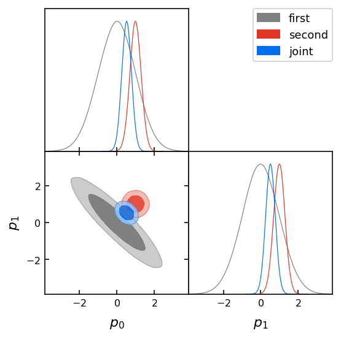

```python
g = plots.get_subplot_plotter()
g.triangle_plot([chain_1, chain_2, chain_12], filled=True)
```

Clearly if we were to look only at the marginalized posteriors of the two distributions we would probably not guess that the two chains are in tension with each other. We next proceed to the calculation of the statistical significance of this tension.

### Parameter shift exact (MCMC) estimates:

We first compute the distribution of parameter shifts and get its compatibility with zero. Since the two input distributions are Gaussian we can compare the results with the exact calculation.

```python
# create the distribution of the parameter differences:
diff_chain = chains_tension.parameter_diff_chain( chain_1, chain_2, boost=1 )
diff_chain.name_tag = 'MCMC difference'
# create the analytic difference distribution to check:
diff_mean  = mean_1 -mean_2
diff_cov   = cov_1 + cov_2
diff_samps = np.random.multivariate_normal( diff_mean, diff_cov, size=nsamp)
diff_chain_analytic = MCSamples( samples = diff_samps,
                                 names   = ["delta_p%s"%i for i in range(ndim)],
                                 labels  = ["\\Delta p_%s"%i for i in range(ndim)],
                                 label   = 'analytic difference' )
```

```
Removed no burn in
```

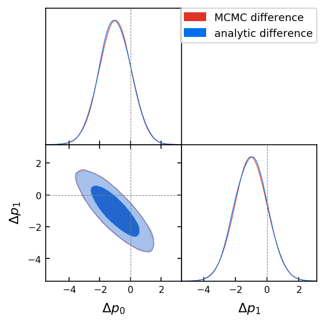

```python
# plot the two distributions:
g = plots.get_subplot_plotter()
g.triangle_plot([diff_chain, diff_chain_analytic], filled=True, markers={'delta_p0':0,'delta_p1':0})
```

As we can see the MCMC difference chain matches well the analytic difference chain. The difference chain is noisier than the input chains. The situation can be improved by boosting the number of samples in the parameter difference distribution at the expense of longer computation times.

We can now compute the statistical significance of this difference from zero. There are two methods for this. One is brute force and works well for short chains and small tensions, the other is nearest neighbour based and works very well for long chains and high tensions. Both methods use all samples and agree. Since, in this case, the chain is fairly long (80k samples) and we know from the previous plot that we are expecting a tension we use the elimination method. You can try to change the method to brute_force and see what changes.

```python
# compute the probability of shift:
shift_probability, shift_lower, shift_upper = chains_tension.exact_parameter_shift( diff_chain, feedback=0, method='nearest_elimination')
```

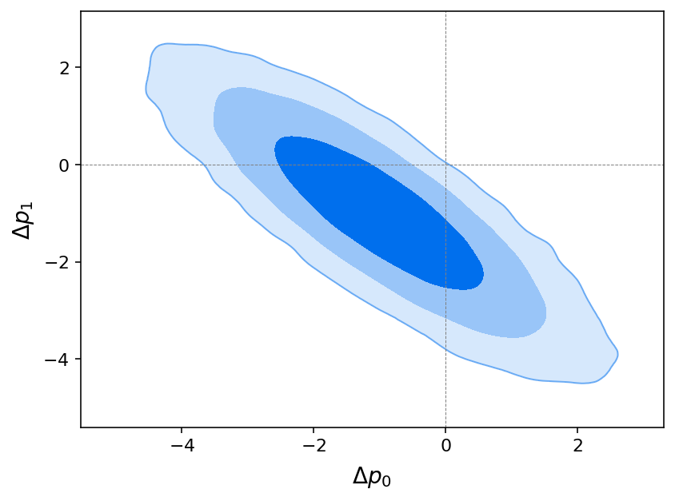

```python
# plot the contour for a sanity check:
g = plots.get_single_plotter()
diff_chain.updateSettings({'contours': [0.68, 0.95, shift_probability]})
g.settings.num_plot_contours = 3
g.plot_2d( diff_chain, 'delta_p0', 'delta_p1', filled=True );
g.add_x_marker(0)
g.add_y_marker(0)
```

This looks in very good agreement given that the difference chain is noisy and the plot smoothing is likely enlarging the contours. Since the input distributions are Gaussian we can check the results with the Gaussian case:

```python
# compute probability of a Gaussian shift:
chi2_probability = scipy.stats.chi2.cdf( np.dot( np.dot( diff_mean, chains_tension.QR_inverse(diff_cov) ), diff_mean ), 2 )
# print the results:
print(f'MCMC shift probability: {shift_probability:.5f} +{shift_upper-shift_probability:.5f} -{shift_probability-shift_lower:.5f}')
print(f'Gaussian probability: {chi2_probability:.5f}')
print(f'Difference: {np.abs(shift_probability-chi2_probability):.5f}')
```

```
MCMC shift probability: 0.99721 +0.00019 -0.00020
Gaussian probability: 0.99482
Difference: 0.00239
```

as we can see the error estimate from the samples is underestimating the difference with the exact result. We can compare this error estimate with the varince of the result that we get from different chains:

```python
# we separate the difference chain:
separate_diff_chains = chains_tension.get_separate_mcsamples(diff_chain)
# then we compute the probability of a shift for each of the chain:
diff_results = np.array([chains_tension.exact_parameter_shift(chain, feedback=0, method='nearest_elimination') for chain in separate_diff_chains])
# then we get the variance of that and divide that by the square root of the number of chains used:
print(f'Chain variance: {np.std(diff_results[:,0])/np.sqrt(nchains):.5f}')
```

```
Chain variance: 0.00053
```

which shows a more realistic picture.

Finally we convert the results to the effective number of sigmas. This is the number of standard deviations that an event from a Gaussian distribution would have given our probability:

```python
# Then we convert the result to the effective number of sigmas:
print(f'MCMC shift nsigma: {chains_tension.from_confidence_to_sigma(shift_probability):.3f}')
print(f'Gaussian nsigma: {chains_tension.from_confidence_to_sigma(chi2_probability):.3f}')
```

```
MCMC shift nsigma: 2.990
Gaussian nsigma: 2.796
```

which agree fairly well, to a fraction of a sigma.

### Gaussian estimators:

We can proceed to compute the statistical significance of the difference in parameters with other estimators, as discussed in https://arxiv.org/abs/1806.04649 . These rely on the Gaussian approximation (though some of them are defined in a way that mitigates possible non-Gaussianities). We start with parameter shifts in standard form Q_DM and in update form Q_UDM:

```python
Q_DM, Q_DM_dofs = chains_tension.Q_DM( chain_1, chain_2 )
Q_UDM, Q_UDM_dofs =chains_tension.Q_UDM( chain_1, chain_12, cutoff=1. )
Q_DM_P = scipy.stats.chi2.cdf(Q_DM, Q_DM_dofs)
Q_UDM_P = scipy.stats.chi2.cdf(Q_UDM, Q_UDM_dofs)
Q_DM_nsigma = chains_tension.from_confidence_to_sigma(Q_DM_P)
Q_UDM_nsigma = chains_tension.from_confidence_to_sigma(Q_UDM_P)
print(f'Q_DM = {Q_DM:.2f}, dofs = {Q_DM_dofs:2}, P = {Q_DM_P:.5f}, nsigma = {Q_DM_nsigma:.3f}')
print(f'Q_UDM = {Q_UDM:.2f}, dofs = {Q_UDM_dofs:2}, P = {Q_UDM_P:.5f}, nsigma = {Q_UDM_nsigma:.3f}')
```

```
Q_DM = 10.57, dofs =  2, P = 0.99493, nsigma = 2.803
Q_UDM = 10.55, dofs =  2, P = 0.99489, nsigma = 2.800
```

That we see match very well, to a fraction of a standard deviation.

We can now test the behavior of Q_UDM:

```python
# verify that Q_UDM is symmetric in the Gaussian case:
print('Symmetric Q_UDM = %.3f, dofs = %2i' % chains_tension.Q_UDM(chain_2, chain_12, cutoff=1.))
# find the optimal cutoff by providing the second chain:
print('Q_UDM optimal cutoff = %.3f' % chains_tension.Q_UDM_get_cutoff(chain_1, chain_2, chain_12)[0])
# get the KL spectrum:
print('Q_UDM KL spectrum:', chains_tension.Q_UDM_KL_components(chain_1, chain_12)[0])
```

```
Symmetric Q_UDM = 10.751, dofs =  2
Q_UDM optimal cutoff = 1.000
Q_UDM KL spectrum: [ 2.10116912 22.12870654]
```

We can proceed to compute the chi squared based version of these estimators. This consists in the statistics of Goodness of fit loss (Q_DMAP) which gives:

```python
Q_DMAP, Q_DMAP_dofs = chains_tension.Q_DMAP(chain_1, chain_2, chain_12, feedback=0 )
Q_DMAP_P = scipy.stats.chi2.cdf(Q_DMAP, Q_DMAP_dofs)
Q_DMAP_nsigma = chains_tension.from_confidence_to_sigma(Q_DMAP_P)
print(f'Q_DMAP = {Q_DMAP:.2f}, dofs = {Q_DMAP_dofs:2}, P = {Q_DMAP_P:.5f}, nsigma = {Q_DMAP_nsigma:.3f}')
```

```
Q_DMAP = 10.53, dofs = 2.0, P = 0.99482, nsigma = 2.796
```

Which is in very good agreement with the previous results, as expected.

## A realistic example, Planck 2018 and DES Y1:

We now turn to a more realistic example that involves a chains from two different (real) experiments. We use the LCDM parameter chains for the results of Planck 2018 (https://arxiv.org/abs/1807.06209) and the results for the Dark Energy Survey (DES) first year of data (https://arxiv.org/abs/1708.01530).

Notice that we have removed many parameters from the chains since they were irrelevant to the example. The chains are already fully polished. Burn in has been removed and the samples have been thinned.

Notice that we have run a prior only chain to ensure that the modeling of the prior is as faithful as possible. In particular, in standard cosmological analyses, we have priors on derived parameters that would give non-trivial shapes to the parameters that are being sampled (see Appendix F in https://arxiv.org/abs/1806.04649)

```python
# load the samples (remove no burn in since the example chains have already been cleaned):
chains_dir = './../example_chains/'
# the Planck 2018 TTTEEE chain:
chain_1 = getdist.mcsamples.loadMCSamples(file_root=chains_dir+'Planck18TTTEEE', no_cache=True)
# the DES Y1 3x2 chain:
chain_2 = getdist.mcsamples.loadMCSamples(file_root=chains_dir+'DES', no_cache=True)
# the joint chain:
chain_12 = getdist.mcsamples.loadMCSamples(file_root=chains_dir+'Planck18TTTEEE_DES', no_cache=True)
# the prior chain:
prior_chain = getdist.mcsamples.loadMCSamples(file_root=chains_dir+'prior', no_cache=True)
```

```
./../example_chains/Planck18TTTEEE_1.txt
./../example_chains/Planck18TTTEEE_2.txt
./../example_chains/Planck18TTTEEE_3.txt
./../example_chains/Planck18TTTEEE_4.txt
./../example_chains/Planck18TTTEEE_5.txt
./../example_chains/Planck18TTTEEE_6.txt
./../example_chains/Planck18TTTEEE_7.txt
./../example_chains/Planck18TTTEEE_8.txt
Removed no burn in
./../example_chains/DES_1.txt
./../example_chains/DES_2.txt
./../example_chains/DES_3.txt
./../example_chains/DES_4.txt
./../example_chains/DES_5.txt
./../example_chains/DES_6.txt
./../example_chains/DES_7.txt
./../example_chains/DES_8.txt
Removed no burn in
./../example_chains/Planck18TTTEEE_DES_1.txt
./../example_chains/Planck18TTTEEE_DES_2.txt
./../example_chains/Planck18TTTEEE_DES_3.txt
./../example_chains/Planck18TTTEEE_DES_4.txt
./../example_chains/Planck18TTTEEE_DES_5.txt
./../example_chains/Planck18TTTEEE_DES_6.txt
./../example_chains/Planck18TTTEEE_DES_7.txt
./../example_chains/Planck18TTTEEE_DES_8.txt
Removed no burn in
./../example_chains/prior_1.txt
./../example_chains/prior_2.txt
./../example_chains/prior_3.txt
./../example_chains/prior_4.txt
./../example_chains/prior_5.txt
./../example_chains/prior_6.txt
./../example_chains/prior_7.txt
./../example_chains/prior_8.txt
Removed no burn in
```

We first plot the chains to get some intuition of what is happening. We show only the parameters that have been run and that the two chains share. These are the only parameters that can contribute to a tension between the two experiments.

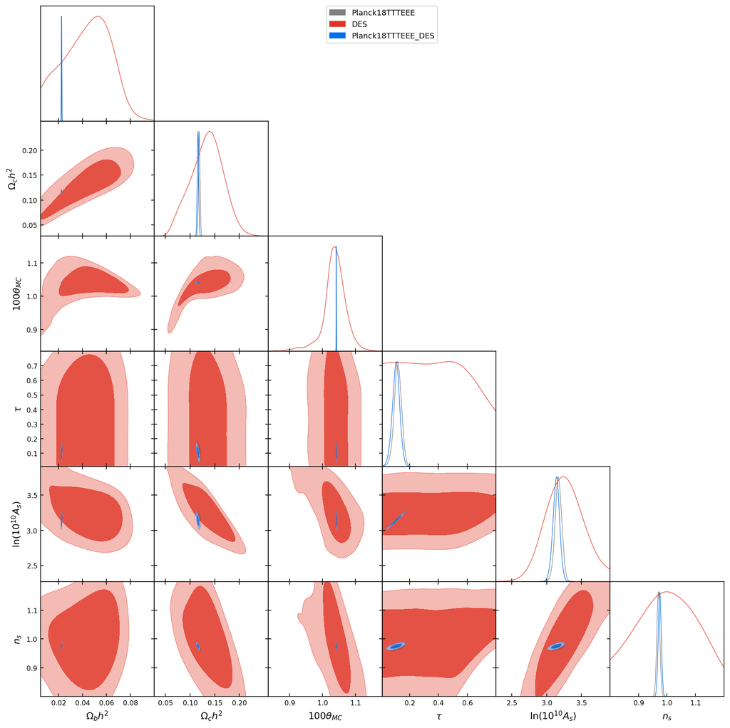

```python
shared_param_names = [name for name in chain_1.getParamNames().getRunningNames()
                      if name in chain_2.getParamNames().getRunningNames()]
g = plots.get_subplot_plotter()
g.triangle_plot([chain_1, chain_2, chain_12], params=shared_param_names, filled=True)
```

Given this plot it is not obvious at all whether the two experiments agree or not.

Moreover, while Planck might still look Gaussian, DES looks like it has a very non-Gaussian posterior.

If we try another parameter combination:

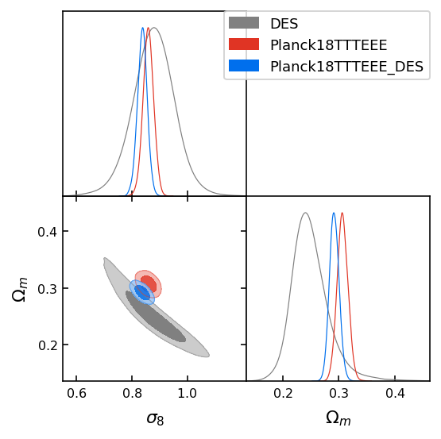

```python
g = plots.get_subplot_plotter()
g.triangle_plot([chain_2, chain_1, chain_12], params=['sigma8','omegam'], filled=True)
```

The situation looks very different. We have selected the two parameters that the weakest data set (DES) best constrains and in this plane the two data sets do not look in agreement. They look fairly similar to our toy example! Coincidence?

The posteriors also look more Gaussian since we are selecting at the best constrained directions. This is a very common problem. When looking at some parameter that is partially informed by the prior the posterior might look non-Gaussian because of prior volume projections.

We can compute the number of parameters that our data sets are truly constraining over the prior.

```python
Neff_1 = chains_tension.get_Neff(chain_1, param_names=shared_param_names, prior_chain=prior_chain)
Neff_2 = chains_tension.get_Neff(chain_2, param_names=shared_param_names, prior_chain=prior_chain)
Neff_12 = chains_tension.get_Neff(chain_12, param_names=shared_param_names, prior_chain=prior_chain)
print(f'Neff(Planck) = {Neff_1:.2f}, Neff(DES) = {Neff_2:.2f}, Neff(joint) = {Neff_12:.2f}')
```

```
Neff(Planck) = 5.98, Neff(DES) = 3.31, Neff(joint) = 5.98
```

It is no surprise that Planck is constraining all six cosmological parameters while DES is constraining three. In addition to the two parameters, that we have shown in the plot above, DES is constraining the angular scale of the BAO peak, as we can see by directly feeding the parameters to use in the calculation:

```python
Neff_2 = chains_tension.get_Neff(chain_2, param_names=['sigma8','omegam','theta_BAO_DES'], prior_chain=prior_chain)
print(f'Neff(DES) = {Neff_2:.2f}')
# the extra 0.5 parameter is a very weak constraint on n_s.
```

```
Neff(DES) = 2.83
```

Since these are real data we can check the Goodness of their fit at maximum posterior.

```python
## in our case the DES data set has 457 data points and the Planck one has 2289
# if we were to normalize the likelihood we need to subtract the normalization factor to get the chi2.
Q_MAP_1 = chains_tension.Q_MAP(chain_1, num_data=2289, prior_chain=prior_chain)
Q_MAP_2 = chains_tension.Q_MAP(chain_2, num_data=457, prior_chain=prior_chain)
Q_MAP_12 = chains_tension.Q_MAP(chain_12, num_data=2289+457, prior_chain=prior_chain)
# get the probability:
Q_MAP_1_P = scipy.stats.chi2.cdf(*Q_MAP_1)
Q_MAP_2_P = scipy.stats.chi2.cdf(*Q_MAP_2)
Q_MAP_12_P = scipy.stats.chi2.cdf(*Q_MAP_12)
# print results:
print(f'Goodness of fit for Planck TTTEEE: Q_MAP = {Q_MAP_1[0]:.3f} with dofs {Q_MAP_1[1]:.3f}')
print(f'Q_MAP probability = {Q_MAP_1_P:.5f}, n_sigma = {chains_tension.from_confidence_to_sigma(Q_MAP_1_P):.3f}\n')
print(f'Goodness of fit for DES: Q_MAP = {Q_MAP_2[0]:.3f} with dofs {Q_MAP_2[1]:.3f}')
print(f'Q_MAP probability = {Q_MAP_2_P:.5f}, n_sigma = {chains_tension.from_confidence_to_sigma(Q_MAP_2_P):.3f}\n')
print(f'Goodness of fit for joint: Q_MAP = {Q_MAP_12[0]:.3f} with dofs {Q_MAP_12[1]:.3f}')
print(f'Q_MAP probability = {Q_MAP_12_P:.5f}, n_sigma = {chains_tension.from_confidence_to_sigma(Q_MAP_12_P):.3f}')
```

```
Goodness of fit for Planck TTTEEE: Q_MAP = 2337.482 with dofs 2283.021
Q_MAP probability = 0.79088, n_sigma = 1.256

Goodness of fit for DES: Q_MAP = 499.154 with dofs 453.685
Q_MAP probability = 0.93106, n_sigma = 1.819

Goodness of fit for joint: Q_MAP = 2850.685 with dofs 2740.021
Q_MAP probability = 0.93113, n_sigma = 1.819
```

Then we check the reliability of the Gaussian approximation:

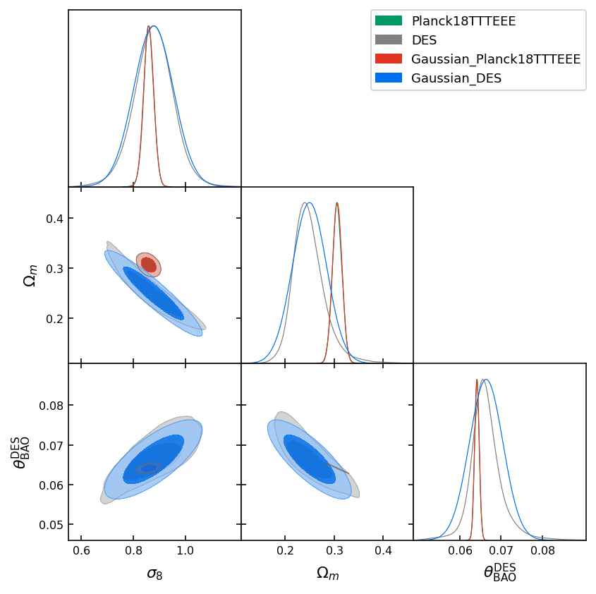

```python
# get the Gaussian approximation:
gaussian_1 = chains_tension.gaussian_approximation(chain_1)
gaussian_2 = chains_tension.gaussian_approximation(chain_2)
# plot for comparison:
g = plots.get_subplot_plotter()
g.triangle_plot([chain_1, chain_2, gaussian_1, gaussian_2], params=['sigma8','omegam','theta_BAO_DES'], filled=True)
```

This looks more Gaussian than the previous plot but still concerning because of clear non-Gaussianities.

### Parameter shift exact (MCMC) estimates:

We then proceed with the calculation of the distribution of parameter shifts.

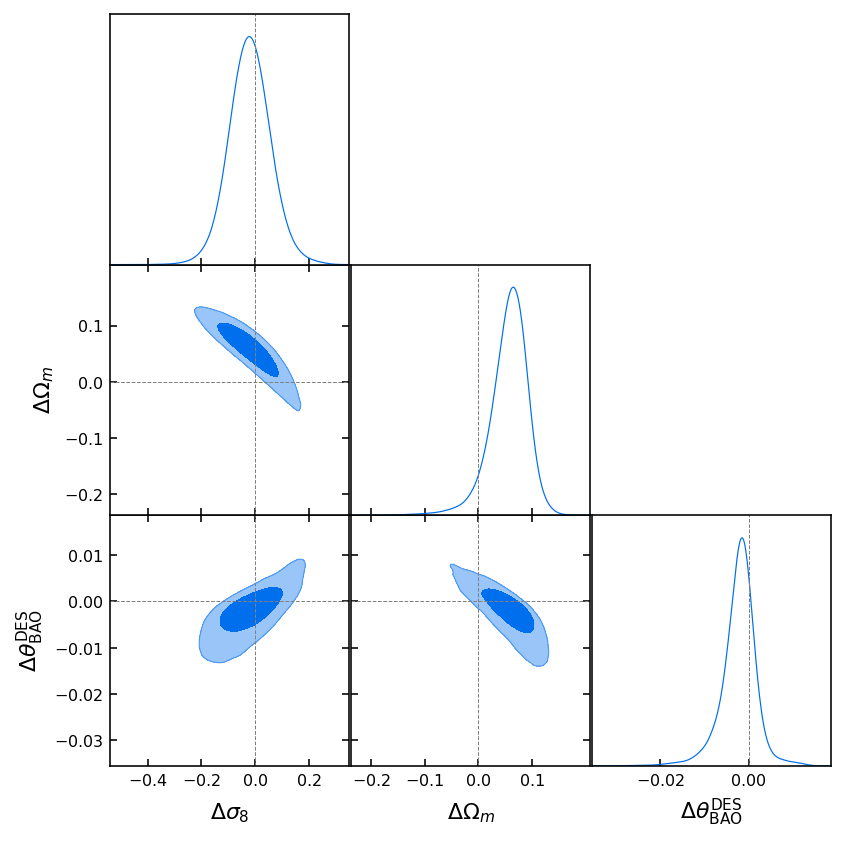

```python
# get the parameter difference chain:
diff_chain = chains_tension.parameter_diff_chain( chain_1, chain_2, boost=4 )
# plot:
g = plots.get_subplot_plotter()
g.triangle_plot([diff_chain], params=['delta_sigma8','delta_omegam','delta_theta_BAO_DES'], filled=True, markers={'delta_sigma8':0,'delta_omegam':0,'delta_theta_BAO_DES':0})
```

We now compute the statistical significance of a shift considering the full parameter space (this will take some time):

```python
exact_shift_P_1, exact_shift_low_1, exact_shift_hi_1 = chains_tension.exact_parameter_shift( diff_chain, feedback=1, method='nearest_elimination' )
print(f'Shift probability considering all parameters = {exact_shift_P_1:.5f} +{exact_shift_hi_1-exact_shift_P_1:.5f} -{exact_shift_P_1-exact_shift_low_1:.5f}')
# turn the result to effective number of sigmas:
print(f'    n_sigma = {chains_tension.from_confidence_to_sigma(exact_shift_P_1):.3f}')
```

```
Neff samples: 1147971.9475684995
Smoothing scale: 0.05343277698800612
Building KD-Tree
Neighbours elimination
nearest_elimination: polishing
    surviving elements 3475 of 1257016
KDE method: nearest_elimination
Time taken for KDE calculation: 249.0 (s)
Shift probability considering all parameters = 0.99738 +0.00004 -0.00004
    n_sigma = 3.009
```

```python
# and we can compare the results with what we would obtain by just considering the three most constrained parameters:
exact_shift_P_2, exact_shift_low_2, exact_shift_hi_2 = chains_tension.exact_parameter_shift( diff_chain, param_names=['delta_sigma8', 'delta_omegam','delta_theta_BAO_DES'], feedback=1, method='nearest_elimination' )
print(f'Shift probability using only the three measured parameters = {exact_shift_P_2:.5f} +{exact_shift_hi_2-exact_shift_P_2:.5f} -{exact_shift_P_2-exact_shift_low_2:.5f}')
# turn the result to effective number of sigmas:
print(f'    n_sigma = {chains_tension.from_confidence_to_sigma(exact_shift_P_2):.3f}')
```

```
Neff samples: 1147971.9475684995
Smoothing scale: 0.017414158339025605
Building KD-Tree
Neighbours elimination
nearest_elimination: polishing
    surviving elements 1777 of 1257016
KDE method: nearest_elimination
Time taken for KDE calculation: 92.8 (s)
Shift probability using only the three measured parameters = 0.99864 +0.00003 -0.00003
    n_sigma = 3.203
```

```python
# let's compute the variance of this result over chains:
separate_diff_chains = chains_tension.get_separate_mcsamples(diff_chain)
diff_results = np.array([chains_tension.exact_parameter_shift(chain, feedback=0, param_names=['delta_sigma8', 'delta_omegam','delta_theta_BAO_DES'], method='nearest_elimination') for chain in separate_diff_chains])
print(f'Chain variance: {np.std(diff_results[:,0])/np.sqrt(len(separate_diff_chains)):.5f}')
```

```
Chain variance: 0.00008
```

As we can see the two results agreee to a fraction of a sigma since we have selected all the parameters that matter (i.e. are constrained by the data and not the prior). Adding n_s to the pool will account for the missing 0.2 sigma in the result. Notice, however, that the time it takes to work in the full parameter space is significantly higher.

We can make a sanity check plot looking at only the two most constrained parameters:

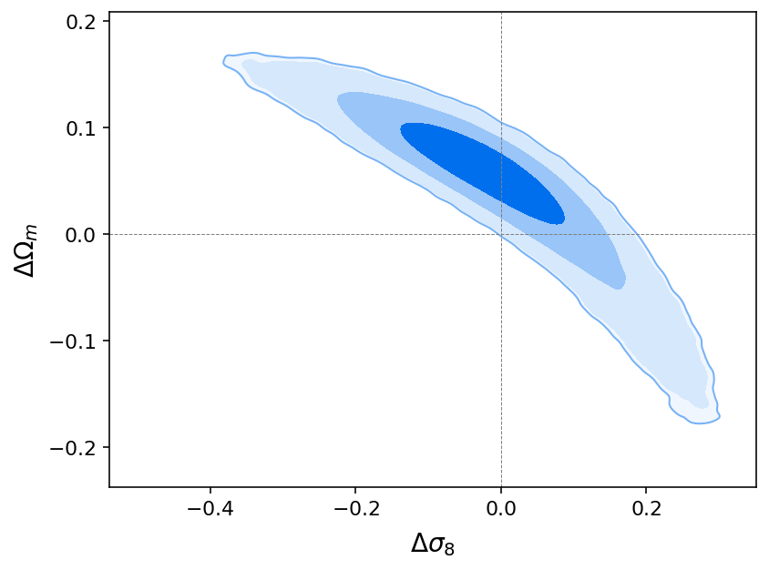

```python
g = plots.get_single_plotter()
diff_chain.updateSettings({'contours': [0.68, 0.95, exact_shift_P_1, exact_shift_P_2]})
g.settings.num_plot_contours = 4
g.plot_2d( diff_chain, 'delta_sigma8', 'delta_omegam', filled=True );
g.add_x_marker(0)
g.add_y_marker(0)
```

### Gaussian estimators:

We start by considering parameter shifts in standard form over the three constrained parameters and over the full parameter space.

```python
# start with Q_DM:
Q_DM = chains_tension.Q_DM(chain_1, chain_2, prior_chain=prior_chain, param_names=['sigma8', 'omegam','theta_BAO_DES'])
Q_DM_full = chains_tension.Q_DM(chain_1, chain_2, prior_chain=prior_chain, param_names=shared_param_names)
# compute probability:
Q_DM_P = scipy.stats.chi2.cdf(*Q_DM)
Q_DM_full_P = scipy.stats.chi2.cdf(*Q_DM_full)
# print results:
print(f'Using only sigma8 and Omegam: Q_DM = {Q_DM[0]:.3f} with dofs {Q_DM[1]:.3f}')
print(f'Q_DM probability = {Q_DM_P:.5f}, n_sigma = {chains_tension.from_confidence_to_sigma(Q_DM_P):.3f}')
print(f'Using all parameters: Q_DM = {Q_DM_full[0]:.3f} with dofs {Q_DM_full[1]:.3f}')
print(f'Q_DM probability = {Q_DM_full_P:.5f}, n_sigma = {chains_tension.from_confidence_to_sigma(Q_DM_full_P):.3f}')
```

```
Using only sigma8 and Omegam: Q_DM = 9.953 with dofs 3.000
Q_DM probability = 0.98103, n_sigma = 2.346
Using all parameters: Q_DM = 4.174 with dofs 5.000
Q_DM probability = 0.47533, n_sigma = 0.636
```

As we can see the result is significantly different and different from what we would expect from the previous results. This happens because, in standard form, Gaussian parameter shifts are not mitigated against non-Gaussianities. Moreover, in the full parameter space the effect of the prior is hard to be removed. As we can see the full parameter space Q_DM is reporting five degrees of freedom which is wrong since we know that that cannot exceed the number of parameters measured by DES (3).

Parameter shifts in update form, that we consider next, offer some mitigation against non-Gaussianities while being more effective at detecting data constrained parameter space directions:

```python
# now Q_UDM:
Q_UDM = chains_tension.Q_UDM(chain_1, chain_12, param_names=['sigma8', 'omegam','theta_BAO_DES'])
Q_UDM_full = chains_tension.Q_UDM(chain_1, chain_12, param_names=shared_param_names)
# compute probability:
Q_UDM_P = scipy.stats.chi2.cdf(*Q_UDM)
Q_UDM_full_P = scipy.stats.chi2.cdf(*Q_UDM_full)
# print results:
print(f'Using only sigma8 and Omegam: Q_UDM = {Q_UDM[0]:.3f} with dofs {Q_UDM[1]:.3f}')
print(f'Q_UDM probability = {Q_UDM_P:.5f}, n_sigma = {chains_tension.from_confidence_to_sigma(Q_UDM_P):.3f}')
print(f'Using all parameters: Q_UDM = {Q_UDM_full[0]:.3f} with dofs {Q_UDM_full[1]:.3f}')
print(f'Q_UDM probability = {Q_UDM_full_P:.5f}, n_sigma = {chains_tension.from_confidence_to_sigma(Q_UDM_full_P):.3f}')
```

```
Using only sigma8 and Omegam: Q_UDM = 11.900 with dofs 2.000
Q_UDM probability = 0.99739, n_sigma = 3.011
Using all parameters: Q_UDM = 12.127 with dofs 2.000
Q_UDM probability = 0.99767, n_sigma = 3.045
```

As we can see these two estimates agree very well with each other since the separation of data constrained directions is more stable. The results also agree very well with the exact result showing that non-Gaussianities are effectively mitigated by considering Planck as the base for the update.

In this case it is important to select as the base for the update parameter shifts the most constraining (and most Gaussian) data set. If we were to use DES (which is non-Gaussian!) as a base for the update we would get a different result:

```python
# now Q_UDM:
Q_UDM = chains_tension.Q_UDM(chain_2, chain_12, param_names=['sigma8', 'omegam','theta_BAO_DES'])
Q_UDM_full = chains_tension.Q_UDM(chain_2, chain_12, param_names=shared_param_names)
# compute probability:
Q_UDM_P = scipy.stats.chi2.cdf(*Q_UDM)
Q_UDM_full_P = scipy.stats.chi2.cdf(*Q_UDM_full)
# print results:
print(f'Using only sigma8 and Omegam: Q_UDM = {Q_UDM[0]:.3f} with dofs {Q_UDM[1]:.3f}')
print(f'Q_UDM probability = {Q_UDM_P:.5f}, n_sigma = {chains_tension.from_confidence_to_sigma(Q_UDM_P):.3f}')
print(f'Using all parameters: Q_UDM = {Q_UDM_full[0]:.3f} with dofs {Q_UDM_full[1]:.3f}')
print(f'Q_UDM probability = {Q_UDM_full_P:.5f}, n_sigma = {chains_tension.from_confidence_to_sigma(Q_UDM_full_P):.3f}')
```

```
Using only sigma8 and Omegam: Q_UDM = 7.028 with dofs 3.000
Q_UDM probability = 0.92898, n_sigma = 1.805
Using all parameters: Q_UDM = 5.475 with dofs 6.000
Q_UDM probability = 0.51552, n_sigma = 0.699
```

which makes no sense because it is heavily contaminated by non-Gaussianities.

Finally we compute Goodness of fit loss:

```python
# at last Q_DMAP:
Q_DMAP = chains_tension.Q_DMAP(chain_1, chain_2, chain_12, prior_chain=prior_chain, param_names=shared_param_names)
Q_DMAP_P = scipy.stats.chi2.cdf(Q_DMAP[0],Q_DMAP[1])
print(f'Using all parameters: Q_DMAP = {Q_DMAP[0]:.3f} with dofs {Q_DMAP[1]:.3f}')
print(f'Q_DMAP probability = {Q_DMAP_P:.5f}, n_sigma = {chains_tension.from_confidence_to_sigma(Q_DMAP_P):.3f}')
```

```
Using all parameters: Q_DMAP = 14.049 with dofs 3.315
Q_DMAP probability = 0.99612, n_sigma = 2.888
```

that we see agrees with the correct result, to a fraction of a sigma.

Possibly some of the discrepancy here is that the estimator is not fully mitigating non-Gaussianities.

Overall we can conclude that a set of reliable estimators agree on a tension between our two input data sets that ranges between 2.8 and 3.2 sigma.